# Project: Investigate a Dataset (No-show appointments)

- Introduction
- Asking Questions
- Data Wrangling
- Exploratory Data Analysis
- Conclusions

## Introduction

### Business Understanding

A person makes a doctor appointment, receives all the instructions and no-show. Who to blame?

This dataset collects information from 110527 medical appointments in Brazil from ('2016-04-29') to ('2016-06-08') and is focused on the question of whether or not patients show up for their appointment.

Problem: Many patients book the appointment with doctor then didn't show up on scheduled day.

Objective of the analysis: Investigate What factors are important for us to know in order to predict if a patient will show up for their scheduled appointment?.

### Features :

- PatientId: Identification of the patient
- AppointmentID: Identification of the appointment
- Gender: M=>Male & F=>Female.
- AppointmentDay: The day of Appointment.
- ScheduledDay: Tells us on what day the patient set up their appointment.
- Age: Patient's age.
- Neighborhood: indicates the location of the hospital.
- Scholarship: indicates whether or not the patient is enrolled in Brasilian [welfare program](https://en.wikipedia.org/wiki/Bolsa_Fam%C3%ADlia)
- Hipertension: True or False
- Diabetes: True or False
- Alcoholism: True or False
- Handcap: handicap rate (0 to 4)
- SMS_received: True or False.
- No-show: True or False.

Data set url noshowappointments

```python
import numpy as np
import pandas as pd
%matplotlib inline
import matplotlib.pyplot as plt
import seaborn as sns

sns.set()
```

## 1- Asking Questions

Q1 Is there any Correlation between features and patient's show up?

Q2 Is SMS_received , gender and scholarship affect the patient's show up?

Q3 Is any deseases (Hipertension , Diabetes or Handcap ) affect the patient's show up?

Q4 Is Appointment Day of the week and the month affect the patient's show up?

Q5 Is Alcoholism affect the patient's show up?

Q6 Is the average of age affect the patient's show up?

Q7 Is the waiting days affect the patient's show up?

Q8 What factors areimportant for us to know in order to predict if a patient will show up for their scheduled appointment up?

## 2- Data Wrangling

- Gathering Data
- Assessing Data
- Cleaning Data

### a) Gathering Data

- As mentiond before in introduction DataSet downloaded from noshowappointments

```python
df=pd.read_csv(r'noshowappointments-KaggleV2-May-2016.csv')
df.head()
```

|  | PatientId | AppointmentID | Gender | ScheduledDay | AppointmentDay | Age | Neighbourhood | Scholarship | Hipertension | Diabetes | Alcoholism | Handcap | SMS_received | No-show |
| --- | --- | --- | --- | --- | --- | --- | --- | --- | --- | --- | --- | --- | --- | --- |
| 0 | 2.987250e+13 | 5642903 | F | 2016-04-29T18:38:08Z | 2016-04-29T00:00:00Z | 62 | JARDIM DA PENHA | 0 | 1 | 0 | 0 | 0 | 0 | No |
| 1 | 5.589978e+14 | 5642503 | M | 2016-04-29T16:08:27Z | 2016-04-29T00:00:00Z | 56 | JARDIM DA PENHA | 0 | 0 | 0 | 0 | 0 | 0 | No |
| 2 | 4.262962e+12 | 5642549 | F | 2016-04-29T16:19:04Z | 2016-04-29T00:00:00Z | 62 | MATA DA PRAIA | 0 | 0 | 0 | 0 | 0 | 0 | No |
| 3 | 8.679512e+11 | 5642828 | F | 2016-04-29T17:29:31Z | 2016-04-29T00:00:00Z | 8 | PONTAL DE CAMBURI | 0 | 0 | 0 | 0 | 0 | 0 | No |
| 4 | 8.841186e+12 | 5642494 | F | 2016-04-29T16:07:23Z | 2016-04-29T00:00:00Z | 56 | JARDIM DA PENHA | 0 | 1 | 1 | 0 | 0 | 0 | No |

### b) Assessing Data

```python
df.info()
```

```
<class 'pandas.core.frame.DataFrame'>
RangeIndex: 110527 entries, 0 to 110526
Data columns (total 14 columns):
 #   Column          Non-Null Count   Dtype
---  ------          --------------   -----
 0   PatientId       110527 non-null  float64
 1   AppointmentID   110527 non-null  int64
 2   Gender          110527 non-null  object
 3   ScheduledDay    110527 non-null  object
 4   AppointmentDay  110527 non-null  object
 5   Age             110527 non-null  int64
 6   Neighbourhood   110527 non-null  object
 7   Scholarship     110527 non-null  int64
 8   Hipertension    110527 non-null  int64
 9   Diabetes        110527 non-null  int64
 10  Alcoholism      110527 non-null  int64
 11  Handcap         110527 non-null  int64
 12  SMS_received    110527 non-null  int64
 13  No-show         110527 non-null  object
dtypes: float64(1), int64(8), object(5)
memory usage: 11.8+ MB
```

- as we can see there are 14 feature columns and 110527 row with out any null values.
- PatientId and AppointmentID features hasn't predict power because so:
  - remove PatientId column.
  - remove AppointmentID column.
- some data types need to be converted :
  - ScheduledDay to datetime
  - AppointmentDay to datetime
- Check duplicated rows.

```python
df.duplicated().sum()
```

```
0
```

- there is no dublicated rows

```python
df['Gender'].value_counts()
```

```
F    71840
M    38687
Name: Gender, dtype: int64
```

- map M to male and F to female is better representive

```python
df['No-show'].value_counts()
```

```
No     88208
Yes    22319
Name: No-show, dtype: int64
```

- Convert No-show to is show to reduse confusion:
  - this required map yes to 0 and no to 1 and then convert column data type to int
- rename all columns to lower case and split tow sections word by _

```python
df['Age'].describe()
```

```
count    110527.000000
mean         37.088874
std          23.110205
min          -1.000000
25%          18.000000
50%          37.000000
75%          55.000000
max         115.000000
Name: Age, dtype: float64
```

```python
df[df['Age']==0]['Age'].count()
```

```
3539
```

- removing data with age < 0 but we will accept the max value 115 because it is possible
- 3539 with age zero acceptable because my born up to 11 month ago.

```python
df.describe()
```

|  | PatientId | AppointmentID | Age | Scholarship | Hipertension | Diabetes | Alcoholism | Handcap | SMS_received |
| --- | --- | --- | --- | --- | --- | --- | --- | --- | --- |
| count | 1.105270e+05 | 1.105270e+05 | 110527.000000 | 110527.000000 | 110527.000000 | 110527.000000 | 110527.000000 | 110527.000000 | 110527.000000 |
| mean | 1.474963e+14 | 5.675305e+06 | 37.088874 | 0.098266 | 0.197246 | 0.071865 | 0.030400 | 0.022248 | 0.321026 |
| std | 2.560949e+14 | 7.129575e+04 | 23.110205 | 0.297675 | 0.397921 | 0.258265 | 0.171686 | 0.161543 | 0.466873 |
| min | 3.921784e+04 | 5.030230e+06 | -1.000000 | 0.000000 | 0.000000 | 0.000000 | 0.000000 | 0.000000 | 0.000000 |
| 25% | 4.172614e+12 | 5.640286e+06 | 18.000000 | 0.000000 | 0.000000 | 0.000000 | 0.000000 | 0.000000 | 0.000000 |
| 50% | 3.173184e+13 | 5.680573e+06 | 37.000000 | 0.000000 | 0.000000 | 0.000000 | 0.000000 | 0.000000 | 0.000000 |
| 75% | 9.439172e+13 | 5.725524e+06 | 55.000000 | 0.000000 | 0.000000 | 0.000000 | 0.000000 | 0.000000 | 1.000000 |
| max | 9.999816e+14 | 5.790484e+06 | 115.000000 | 1.000000 | 1.000000 | 1.000000 | 1.000000 | 4.000000 | 1.000000 |

```python
df.Handcap.value_counts()
```

```
0    108286
1      2042
2       183
3        13
4         3
Name: Handcap, dtype: int64
```

- rename Handcap column to handicap

### Assess conclusions:

- Remove PatientId column.
- Remove AppointmentID column.
- Convert ScheduledDay column datatype to datetime
- Convert AppointmentDay column datatype to datetime
- map M to male and F to female better representive
- Convert No-show to is show to reduse confusion and map yes to 0 and no to 1 and then convert column data type to int.
- rename all columns to lower case and split tow sections word by _
- removing data with age < 0
- rename Handcap column to handicap

### b) Cleaning Data

#### steps:

1- Copy data fram to new one

```python
df_new=df.copy()
```

2- Remove un needed columns PatientId and AppointmentID

```python
df_new.drop(columns=['PatientId','AppointmentID'],inplace=True)
df_new.head()
```

|  | Gender | ScheduledDay | AppointmentDay | Age | Neighbourhood | Scholarship | Hipertension | Diabetes | Alcoholism | Handcap | SMS_received | No-show |
| --- | --- | --- | --- | --- | --- | --- | --- | --- | --- | --- | --- | --- |
| 0 | F | 2016-04-29T18:38:08Z | 2016-04-29T00:00:00Z | 62 | JARDIM DA PENHA | 0 | 1 | 0 | 0 | 0 | 0 | No |
| 1 | M | 2016-04-29T16:08:27Z | 2016-04-29T00:00:00Z | 56 | JARDIM DA PENHA | 0 | 0 | 0 | 0 | 0 | 0 | No |
| 2 | F | 2016-04-29T16:19:04Z | 2016-04-29T00:00:00Z | 62 | MATA DA PRAIA | 0 | 0 | 0 | 0 | 0 | 0 | No |
| 3 | F | 2016-04-29T17:29:31Z | 2016-04-29T00:00:00Z | 8 | PONTAL DE CAMBURI | 0 | 0 | 0 | 0 | 0 | 0 | No |
| 4 | F | 2016-04-29T16:07:23Z | 2016-04-29T00:00:00Z | 56 | JARDIM DA PENHA | 0 | 1 | 1 | 0 | 0 | 0 | No |

3- Convert ScheduledDay and AppointmentDay to datatime data type

```python
df_new['ScheduledDay']=pd.to_datetime(df_new['ScheduledDay'])
df_new['AppointmentDay']=pd.to_datetime(df_new['AppointmentDay'])
df_new.info()
```

```
<class 'pandas.core.frame.DataFrame'>
RangeIndex: 110527 entries, 0 to 110526
Data columns (total 12 columns):
 #   Column          Non-Null Count   Dtype
---  ------          --------------   -----
 0   Gender          110527 non-null  object
 1   ScheduledDay    110527 non-null  datetime64[ns, UTC]
 2   AppointmentDay  110527 non-null  datetime64[ns, UTC]
 3   Age             110527 non-null  int64
 4   Neighbourhood   110527 non-null  object
 5   Scholarship     110527 non-null  int64
 6   Hipertension    110527 non-null  int64
 7   Diabetes        110527 non-null  int64
 8   Alcoholism      110527 non-null  int64
 9   Handcap         110527 non-null  int64
 10  SMS_received    110527 non-null  int64
 11  No-show         110527 non-null  object
dtypes: datetime64[ns, UTC](2), int64(7), object(3)
memory usage: 10.1+ MB
```

4 - map M to male and F to female

```python
df_new['Gender']=df_new['Gender'].map({'M':'male','F':'female'})
df_new['Gender'].value_counts()
```

```
female    71840
male      38687
Name: Gender, dtype: int64
```

```python
df_new.shape
```

```
(110527, 12)
```

4 - removing data with age less than 0

```python
df_new=df_new[df_new['Age']>=0]
df_new.shape
```

```
(110526, 12)
```

5 rename columns:

- rename all columns to lower case and split tow sections word by _
- rename Handcap column to handicap

```python
df_new.columns.values
```

```
array(['Gender', 'ScheduledDay', 'AppointmentDay', 'Age', 'Neighbourhood',
       'Scholarship', 'Hipertension', 'Diabetes', 'Alcoholism', 'Handcap',
       'SMS_received', 'No-show'], dtype=object)
```

```python
df_new.rename(columns=lambda x:x.lower().replace('-','_'),inplace=True)
df_new.columns.values
```

```
array(['gender', 'scheduledday', 'appointmentday', 'age', 'neighbourhood',
       'scholarship', 'hipertension', 'diabetes', 'alcoholism', 'handcap',
       'sms_received', 'no_show'], dtype=object)
```

```python
df_new.rename(columns={'scheduledday':'scheduled_day','appointmentday':'appointment_day','handcap':'handicap'},inplace=True)
df_new.columns.values
```

```
array(['gender', 'scheduled_day', 'appointment_day', 'age',
       'neighbourhood', 'scholarship', 'hipertension', 'diabetes',
       'alcoholism', 'handicap', 'sms_received', 'no_show'], dtype=object)
```

6 - Convert No-show to is show to reduse confusion and map yes to 0 and no to 1 and then convert column data type to int.

```python
df_new['no_show']=df_new['no_show'].map({'Yes':0,'No':1})
df_new.rename(columns={'no_show':'show'},inplace=True)
df_new['show']=df_new['show'].astype(int)
df_new['show'].value_counts()
```

```
1    88207
0    22319
Name: show, dtype: int64
```

7 - adding new column to diffrence between Scheduled Day and Appointment Day

```python
df_new['waiting_days']=df_new['appointment_day']-df_new['scheduled_day']
df_new['waiting_days'].describe()
```

```
count                        110526
mean      9 days 17:08:42.047952517
std      15 days 05:51:31.240428096
min               -7 days +10:10:40
25%               -1 days +15:41:32
50%                 3 days 11:22:33
75%         14 days 07:41:37.750000
max               178 days 13:19:01
Name: waiting_days, dtype: object
```

```python
df_new['waiting_days']=df_new['waiting_days'].astype(str).apply(lambda x:x.split()[0]).astype(int)
df_new['waiting_days'].describe()
```

```
count    110526.000000
mean          9.183794
std          15.255034
min          -7.000000
25%          -1.000000
50%           3.000000
75%          14.000000
max         178.000000
Name: waiting_days, dtype: float64
```

```python
df_new=df_new[df_new['waiting_days'] >=0]
```

```python
df_new.describe(include='all')
```

|  | gender | scheduled_day | appointment_day | age | neighbourhood | scholarship | hipertension | diabetes | alcoholism | handicap | sms_received | show | waiting_days |
| --- | --- | --- | --- | --- | --- | --- | --- | --- | --- | --- | --- | --- | --- |
| count | 71959 | 71959 | 71959 | 71959.000000 | 71959 | 71959.000000 | 71959.000000 | 71959.000000 | 71959.000000 | 71959.000000 | 71959.000000 | 71959.000000 | 71959.000000 |
| unique | 2 | 68666 | 27 | NaN | 80 | NaN | NaN | NaN | NaN | NaN | NaN | NaN | NaN |
| top | female | 2016-04-25 17:17:46+00:00 | 2016-06-06 00:00:00+00:00 | NaN | JARDIM CAMBURI | NaN | NaN | NaN | NaN | NaN | NaN | NaN | NaN |
| freq | 48070 | 22 | 3073 | NaN | 5213 | NaN | NaN | NaN | NaN | NaN | NaN | NaN | NaN |
| first | NaN | 2015-11-10 07:13:56+00:00 | 2016-04-29 00:00:00+00:00 | NaN | NaN | NaN | NaN | NaN | NaN | NaN | NaN | NaN | NaN |
| last | NaN | 2016-06-07 19:03:57+00:00 | 2016-06-08 00:00:00+00:00 | NaN | NaN | NaN | NaN | NaN | NaN | NaN | NaN | NaN | NaN |
| mean | NaN | NaN | NaN | 38.502564 | NaN | 0.092706 | 0.208897 | 0.074723 | 0.025320 | 0.020025 | 0.493086 | 0.714810 | 14.642018 |
| std | NaN | NaN | NaN | 22.925421 | NaN | 0.290021 | 0.406523 | 0.262946 | 0.157096 | 0.154072 | 0.499956 | 0.451508 | 16.494334 |
| min | NaN | NaN | NaN | 0.000000 | NaN | 0.000000 | 0.000000 | 0.000000 | 0.000000 | 0.000000 | 0.000000 | 0.000000 | 0.000000 |
| 25% | NaN | NaN | NaN | 19.000000 | NaN | 0.000000 | 0.000000 | 0.000000 | 0.000000 | 0.000000 | 0.000000 | 0.000000 | 3.000000 |
| 50% | NaN | NaN | NaN | 39.000000 | NaN | 0.000000 | 0.000000 | 0.000000 | 0.000000 | 0.000000 | 0.000000 | 1.000000 | 8.000000 |
| 75% | NaN | NaN | NaN | 57.000000 | NaN | 0.000000 | 0.000000 | 0.000000 | 0.000000 | 0.000000 | 1.000000 | 1.000000 | 21.000000 |
| max | NaN | NaN | NaN | 115.000000 | NaN | 1.000000 | 1.000000 | 1.000000 | 1.000000 | 4.000000 | 1.000000 | 1.000000 | 178.000000 |

8- split appointment_day and scheduled_day into date , time , hour and day of the week to make more analysis

```python
df_new['appointment_date']=df_new['appointment_day'].dt.date
df_new['appointment_time']=df_new['appointment_day'].dt.time
df_new['appointment_dow']=df_new['appointment_day'].dt.day_name()
df_new['appointment_hour']=df_new['appointment_day'].dt.hour
df_new['appointment_month']=df_new['appointment_day'].dt.month_name()
```

```python
df_new.sample(10)
```

|  | gender | scheduled_day | appointment_day | age | neighbourhood | scholarship | hipertension | diabetes | alcoholism | handicap | sms_received | show | waiting_days | appointment_date | appointment_time | appointment_dow | appointment_hour | appointment_month |
| --- | --- | --- | --- | --- | --- | --- | --- | --- | --- | --- | --- | --- | --- | --- | --- | --- | --- | --- |
| 60215 | male | 2016-04-27 10:19:11+00:00 | 2016-05-19 00:00:00+00:00 | 4 | CENTRO | 0 | 0 | 0 | 0 | 0 | 0 | 1 | 21 | 2016-05-19 | 00:00:00 | Thursday | 0 | May |
| 41703 | female | 2016-05-12 07:27:21+00:00 | 2016-05-16 00:00:00+00:00 | 72 | SÃO JOSÉ | 0 | 1 | 0 | 0 | 0 | 0 | 1 | 3 | 2016-05-16 | 00:00:00 | Monday | 0 | May |
| 69444 | female | 2016-04-27 09:02:58+00:00 | 2016-05-02 00:00:00+00:00 | 17 | SÃO CRISTÓVÃO | 0 | 0 | 0 | 0 | 0 | 1 | 0 | 4 | 2016-05-02 | 00:00:00 | Monday | 0 | May |
| 79445 | female | 2016-05-04 07:42:24+00:00 | 2016-05-12 00:00:00+00:00 | 44 | ILHA DAS CAIEIRAS | 1 | 0 | 0 | 0 | 0 | 1 | 1 | 7 | 2016-05-12 | 00:00:00 | Thursday | 0 | May |
| 91170 | female | 2016-05-12 15:59:23+00:00 | 2016-06-02 00:00:00+00:00 | 19 | GRANDE VITÓRIA | 1 | 0 | 0 | 0 | 0 | 1 | 1 | 20 | 2016-06-02 | 00:00:00 | Thursday | 0 | June |
| 96522 | male | 2016-05-04 14:46:54+00:00 | 2016-06-02 00:00:00+00:00 | 45 | JARDIM DA PENHA | 0 | 0 | 0 | 0 | 0 | 1 | 1 | 28 | 2016-06-02 | 00:00:00 | Thursday | 0 | June |
| 105966 | female | 2016-04-26 15:17:48+00:00 | 2016-06-03 00:00:00+00:00 | 58 | SANTA MARTHA | 0 | 0 | 0 | 0 | 0 | 1 | 1 | 37 | 2016-06-03 | 00:00:00 | Friday | 0 | June |
| 31045 | female | 2016-04-19 12:01:24+00:00 | 2016-05-06 00:00:00+00:00 | 56 | BENTO FERREIRA | 0 | 0 | 0 | 0 | 0 | 1 | 0 | 16 | 2016-05-06 | 00:00:00 | Friday | 0 | May |
| 79296 | male | 2016-05-12 10:50:42+00:00 | 2016-05-16 00:00:00+00:00 | 25 | JARDIM DA PENHA | 0 | 0 | 0 | 0 | 0 | 0 | 0 | 3 | 2016-05-16 | 00:00:00 | Monday | 0 | May |
| 39466 | female | 2016-05-12 16:42:52+00:00 | 2016-05-17 00:00:00+00:00 | 28 | FONTE GRANDE | 0 | 0 | 0 | 0 | 0 | 0 | 0 | 4 | 2016-05-17 | 00:00:00 | Tuesday | 0 | May |

```python
df_new['appointment_time'].nunique()
```

```
1
```

9- Drop it and appointment_hour because all rows with the same appointment_time .

```python
df_new.drop(columns=['appointment_time','appointment_hour'],inplace=True)
df_new.sample(10)
```

|  | gender | scheduled_day | appointment_day | age | neighbourhood | scholarship | hipertension | diabetes | alcoholism | handicap | sms_received | show | waiting_days | appointment_date | appointment_dow | appointment_month |
| --- | --- | --- | --- | --- | --- | --- | --- | --- | --- | --- | --- | --- | --- | --- | --- | --- |
| 59833 | female | 2016-04-26 07:15:11+00:00 | 2016-05-05 00:00:00+00:00 | 65 | JUCUTUQUARA | 0 | 0 | 0 | 0 | 0 | 1 | 0 | 8 | 2016-05-05 | Thursday | May |
| 36469 | female | 2016-04-15 08:51:23+00:00 | 2016-05-17 00:00:00+00:00 | 28 | CARATOÍRA | 0 | 0 | 0 | 0 | 0 | 0 | 1 | 31 | 2016-05-17 | Tuesday | May |
| 33658 | male | 2016-05-16 13:35:10+00:00 | 2016-05-18 00:00:00+00:00 | 76 | SÃO JOSÉ | 0 | 1 | 0 | 0 | 0 | 0 | 0 | 1 | 2016-05-18 | Wednesday | May |
| 17504 | female | 2016-05-17 12:59:08+00:00 | 2016-05-18 00:00:00+00:00 | 0 | SÃO JOSÉ | 0 | 0 | 0 | 0 | 0 | 0 | 1 | 0 | 2016-05-18 | Wednesday | May |
| 41555 | female | 2016-05-17 12:27:16+00:00 | 2016-05-19 00:00:00+00:00 | 46 | PRAIA DO CANTO | 0 | 0 | 0 | 0 | 0 | 0 | 1 | 1 | 2016-05-19 | Thursday | May |
| 33095 | female | 2016-05-06 07:16:47+00:00 | 2016-05-12 00:00:00+00:00 | 26 | SANTO ANTÔNIO | 0 | 0 | 0 | 0 | 0 | 1 | 0 | 5 | 2016-05-12 | Thursday | May |
| 45876 | male | 2016-04-29 09:13:17+00:00 | 2016-05-20 00:00:00+00:00 | 3 | CENTRO | 0 | 0 | 0 | 0 | 0 | 0 | 1 | 20 | 2016-05-20 | Friday | May |
| 33690 | female | 2016-05-16 13:38:29+00:00 | 2016-05-18 00:00:00+00:00 | 40 | GURIGICA | 0 | 0 | 0 | 0 | 0 | 0 | 0 | 1 | 2016-05-18 | Wednesday | May |
| 94469 | female | 2016-05-30 13:45:17+00:00 | 2016-06-02 00:00:00+00:00 | 49 | DA PENHA | 0 | 1 | 1 | 0 | 0 | 1 | 1 | 2 | 2016-06-02 | Thursday | June |
| 2763 | female | 2016-04-19 07:36:44+00:00 | 2016-04-29 00:00:00+00:00 | 43 | SANTO ANDRÉ | 1 | 1 | 0 | 0 | 0 | 1 | 0 | 9 | 2016-04-29 | Friday | April |

- now , we finished cleaning data so save data to csv and then start EDA

```python
df_new.to_csv('noshowappointments_cleaned.csv',index=False)
```

## Exploratory Data Analysis

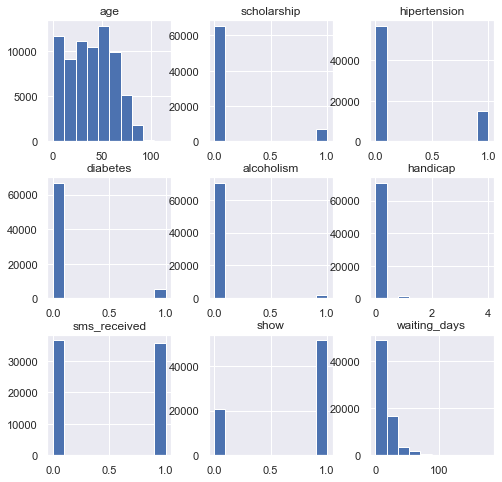

```python
df_cleaned=pd.read_csv(r'noshowappointments_cleaned.csv')
df_cleaned.hist(figsize=(8,8));
```

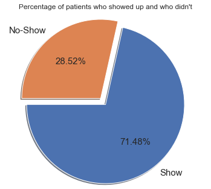

```python
label_Names = ["Show", "No-Show"]
data = [df_cleaned.query('show == 1').count()[0], df_cleaned.query('show == 0').count()[0]]
explode = (0, 0.15)
plt.axis('equal');
plt.pie(data,radius=1.5,shadow=True ,labels = label_Names,explode=explode, startangle=180,autopct='%0.2f%%',textprops = {"fontsize":15})
plt.title("Percentage of patients who showed up and who didn't",y=1.2);
```

### Research Question 1 (Is there any Correlation between features and patient's show?)

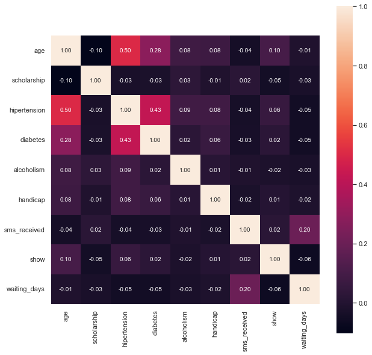

```python
correlation = df_cleaned.corr()
fig, axes = plt.subplots(figsize=(10,10))
sns.heatmap(correlation, vmax=1, cbar=True, annot=True, square=True, fmt='.2f', annot_kws={'size': 10});
```

- Heatmap shows three correlations:
  - hipertension and age
  - hipertension and diabetes
  - diabetes and age
- There is no strong correlation between any feature with show

### Research Question 2 (Is SMS_received , gender and scholarship affect the patient's show?)

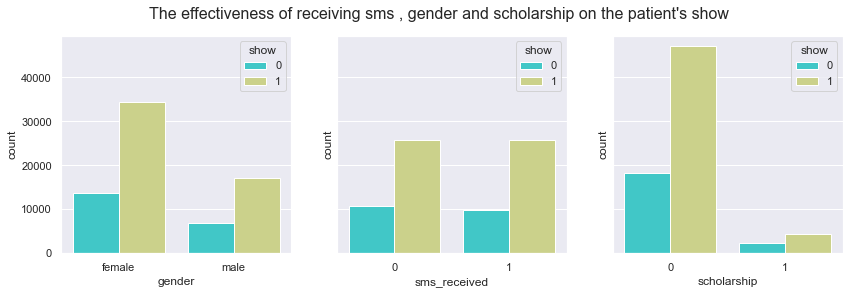

```python
fig, (ax1, ax2, ax3) = plt.subplots(ncols=3, sharey=True)
sns.countplot(x='gender', data=df_cleaned, hue='show', ax=ax1, palette='rainbow')
sns.countplot(x='sms_received', data=df_cleaned, hue='show', ax=ax2, palette='rainbow')
sns.countplot(x='scholarship', data=df_cleaned, hue='show', ax=ax3, palette='rainbow')
fig.set_figwidth(14)
fig.set_figheight(4)
fig.suptitle("The effectiveness of receiving sms , gender and scholarship on the patient's show", fontsize=16);
```

- from bar chart of gender we found females percentage greatter than males

```python
df_cleaned['gender'].value_counts()
```

```
female    48070
male      23889
Name: gender, dtype: int64
```

```python
male_percentage=(df_cleaned['gender'].value_counts()[1]/df_cleaned['gender'].value_counts().sum())*100
male_percentage
```

```
33.1980711238344
```

```python
df_cleaned.query('show==1')['gender'].value_counts()
```

```
female    34396
male      17041
Name: gender, dtype: int64
```

```python
male_ratio=df_cleaned.query('show==1')['gender'].value_counts()[1]/df_cleaned['gender'].value_counts()[1]
female_ratio=df_cleaned.query('show==1')['gender'].value_counts()[0]/df_cleaned['gender'].value_counts()[0]
female_ratio,male_ratio
```

```
(0.7155398377366341, 0.7133408681820085)
```

- Both genders have same commitment to medical schedules. (71 %)
- sms doesn't affect on patient's show
- this data is imbalanced because males represent 33.2% of observations
- Number of patients who have scholarship is very small

### Research Question 3 (are deseases like Hipertension , Diabetes and Handicap affect the patient's show?)

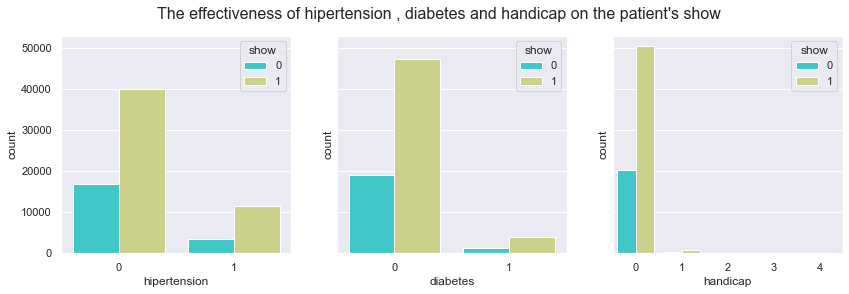

```python
fig, (ax1, ax2, ax3) = plt.subplots(ncols=3, sharey=True)
sns.countplot(x='hipertension', data=df_cleaned, hue='show', ax=ax1, palette='rainbow')
sns.countplot(x='diabetes', data=df_cleaned, hue='show', ax=ax2, palette='rainbow')
sns.countplot(x='handicap', data=df_cleaned, hue='show', ax=ax3, palette='rainbow')
fig.set_figwidth(14)
fig.set_figheight(4)
fig.suptitle("The effectiveness of hipertension , diabetes and handicap on the patient's show", fontsize=16);
```

### Research Question 4 (Is Appointment Day of the week affect the patient's show?)

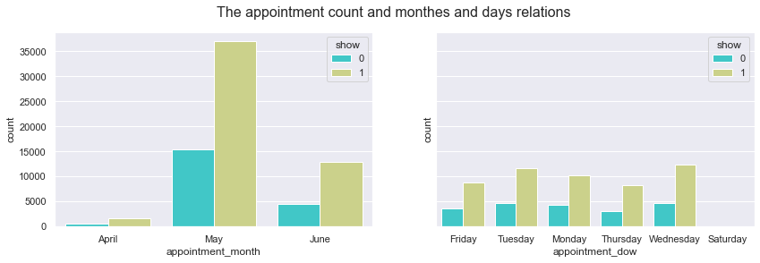

```python
fig, (ax1, ax2) = plt.subplots(ncols=2, sharey=True)
sns.countplot(x='appointment_month', data=df_cleaned, hue='show', ax=ax1, palette='rainbow')
sns.countplot(x='appointment_dow', data=df_cleaned, hue='show', ax=ax2, palette='rainbow')
fig.set_figwidth(14)
fig.set_figheight(4)
fig.suptitle("The appointment count and monthes and days relations", fontsize=16);
```

```python
df_cleaned['appointment_dow'].value_counts()
```

```
Wednesday    17044
Tuesday      16462
Monday       14581
Friday       12516
Thursday     11325
Saturday        31
Name: appointment_dow, dtype: int64
```

```python
df_cleaned['appointment_date'].min(),df_cleaned['appointment_date'].max()
```

```
('2016-04-29', '2016-06-08')
```

- 'May' the highest month when patients make appointment , but data already collected from 2016-04-29 to 2016-06-08 so this chart does not give information in terms of the difference between the months
- Tuesday,Wednesday highest days when patients make appointment.
- Saturday lowest ptients appoinment

### Research Question 5 (Is Alcoholism affect the patient's show?)

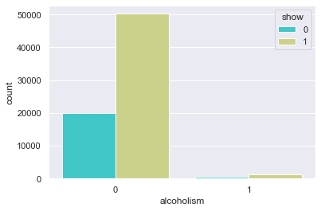

```python
sns.countplot(x='alcoholism', data=df_cleaned, hue='show', palette='rainbow')
fig.set_figwidth(15)
fig.set_figheight(5)
```

- alcoholism has not effect on the patient's show

### Research Question 6 (Is the age affect the patient's show?)

```python
df_cleaned.describe()['age']
```

```
count    71959.000000
mean        38.502564
std         22.925421
min          0.000000
25%         19.000000
50%         39.000000
75%         57.000000
max        115.000000
Name: age, dtype: float64
```

```python
df_age=df_cleaned.copy()
bins=[df_cleaned.describe()['age']['min'],df_cleaned.describe()['age']['25%'],df_cleaned.describe()['age']['50%'],df_cleaned.describe()['age']['75%'],
     df_cleaned.describe()['age']['max']]
bins_labels=['childs','young-adults','middel-age-adults','old-adults']
df_age['age_level']=pd.cut(df_age['age'],bins,labels=bins_labels)
```

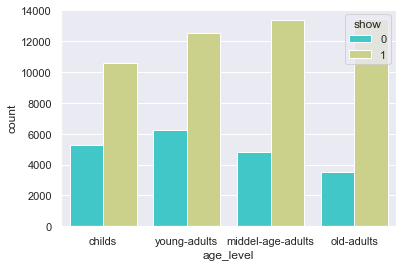

```python
sns.countplot(x='age_level', data=df_age, hue='show', palette='rainbow')
fig.set_figwidth(15)
fig.set_figheight(5)
```

- young adults from 19 to 39 years old are the highest missed show up

### Research Question 7 (Is the waiting days affect the patient's show?)

```python
df_valid_waiting_days=df_cleaned.query('waiting_days >= 0').copy()
df_valid_waiting_days.shape
```

```
(71959, 16)
```

[output not shown]

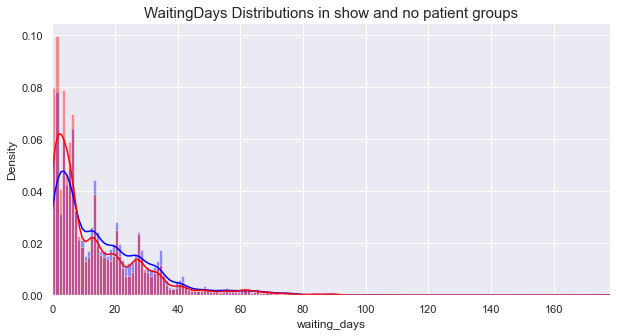

```python
plt.figure(figsize=(10, 5))

sns.distplot(df_valid_waiting_days[df_valid_waiting_days['show'] == 0]["waiting_days"], bins=df_valid_waiting_days['waiting_days'].max(),color='blue' ,kde=True)
sns.distplot(df_valid_waiting_days[df_valid_waiting_days['show'] == 1]["waiting_days"], bins=df_valid_waiting_days['waiting_days'].max(), color='red', kde=True)

plt.title('WaitingDays Distributions in show and no patient groups', fontsize=15)
plt.xlim(df_valid_waiting_days['waiting_days'].min(),df_valid_waiting_days['waiting_days'].max())
plt.show()
```

- waiting days until 7 days patient show up is higher ratio after 7 days missed show up is higher ratio .

### Research Question 8 (What factors areimportant for us to know in order to predict if a patient will show up for their scheduled appointment?)

```python
df_neighbourhood=pd.DataFrame(data=df_cleaned['neighbourhood'].value_counts())
df_neighbourhood.reset_index(level=0, inplace=True)
df_neighbourhood.rename(columns={'neighbourhood':'appointment_count','index':'neighbourhood'},inplace=True)

df_neighbourhood_show =pd.DataFrame(data=df_cleaned.query('show == 1')['neighbourhood'].value_counts())
df_neighbourhood_show.reset_index(level=0, inplace=True)
df_neighbourhood_show.rename(columns={'neighbourhood':'show_count','index':'neighbourhood'},inplace=True)
df_neighbourhood_show

df_neighbourhood_combined=df_neighbourhood.merge(df_neighbourhood_show , left_on='neighbourhood' ,right_on='neighbourhood',how='inner')
df_neighbourhood_combined['show_up_ratio']=df_neighbourhood_combined['show_count']/df_neighbourhood_combined['appointment_count']
df_neighbourhood_combined
```

|  | neighbourhood | appointment_count | show_count | show_up_ratio |
| --- | --- | --- | --- | --- |
| 0 | JARDIM CAMBURI | 5213 | 3854 | 0.739306 |
| 1 | MARIA ORTIZ | 3730 | 2592 | 0.694906 |
| 2 | RESISTÊNCIA | 2818 | 1961 | 0.695884 |
| 3 | JARDIM DA PENHA | 2655 | 2058 | 0.775141 |
| 4 | ITARARÉ | 2381 | 1512 | 0.635027 |
| ... | ... | ... | ... | ... |
| 74 | MORADA DE CAMBURI | 78 | 62 | 0.794872 |
| 75 | PONTAL DE CAMBURI | 41 | 29 | 0.707317 |
| 76 | ILHA DO BOI | 23 | 21 | 0.913043 |
| 77 | ILHA DO FRADE | 8 | 6 | 0.750000 |
| 78 | AEROPORTO | 5 | 4 | 0.800000 |

79 rows × 4 columns

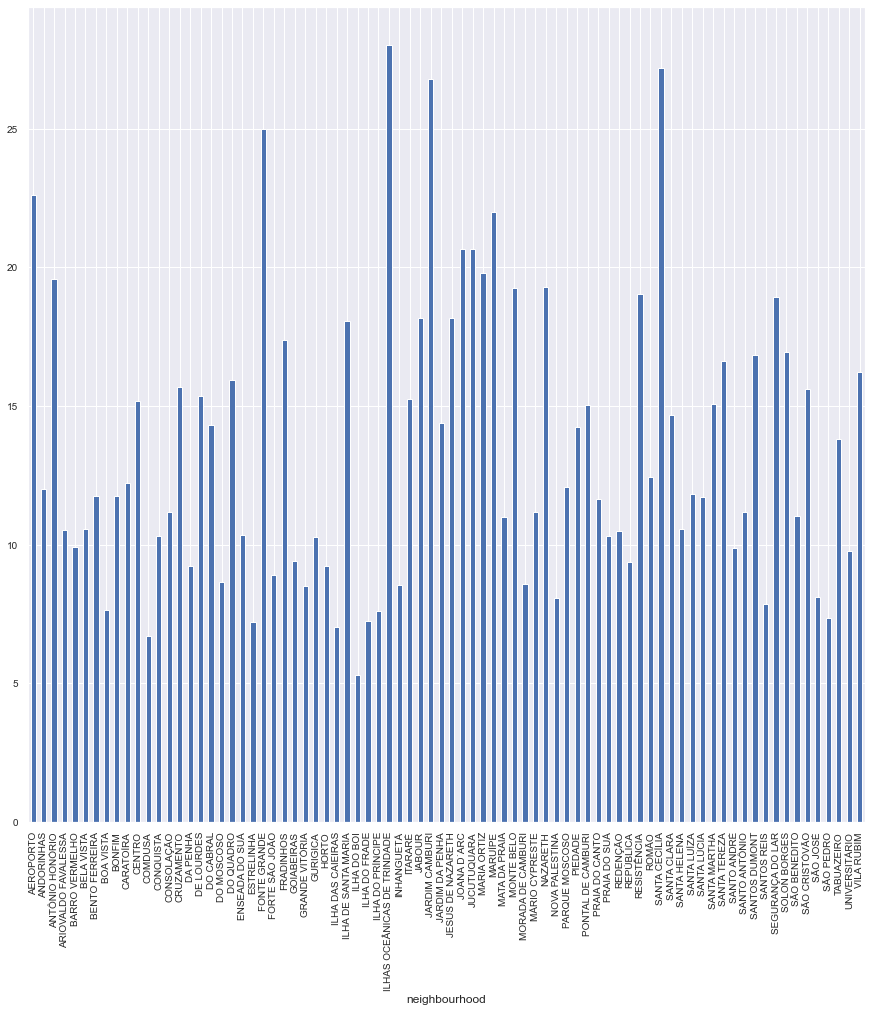

```python
df_cleaned.groupby('neighbourhood')['waiting_days'].mean().plot(kind='bar',figsize=(15,15),fontsize=10);
```